# Control Estadístico de Procesos

MSc Gustavo Ahumada

## Unidades de Aprendizaje

- Unidad I Fundamentos de la Gestión de la Calidad.
- Unidad II Metodlogías Estadísticas Aplicadas a Procesos.
- Unidad III Control Estadístico de Procesos.
- Unidad IV Metodología Seis Sigma

## Evaluaciones

- Solemne I $20\%$ 22 de Abril.
- Solemne II $30\%$ 29 de Mayo.
- Solemne III $30\%$ 26 de Junio.
- Problem set $20\%$.

## Bibliografía

- Control Estadístico de Calidad y 6 Sigma; Gutierrez, H; De la Vara, R.; Mc Graw Hill; 3 Ed. 2009.
- Probabilidad y Estadística Aplicada a la Ingenieria. Montgomery, D.; 2 Ed. Limusa Wiley.
- Control Estadístico de Calidad. Montgomery, D.; 3 Ed. Limusa Wiley.
- Quality Control with R. Cano, E.; Moguerza, J.; Prieto, M. 1 Ed. Springer. 2015.
- Six Sigma with R. Cano, E.; Moguerza, J.; Redchuck, A. 1 Ed. Springer. 2013.

## Que es el Control Estadístico de Procesos?

- Aborda los conceptos asociados a la gestion de la calidad y el mejoramiento continuo de procesos, mediante la aplicación de metodologías como el control estadistco de procesos (CEP) y Seis Sigma.
- Incorpora los conceptos de calidad, mejora continua y la variabilidad de los procesos y sus causas.

Un Ingeniero es alguien que resuelve probelmas de interés para la sociedad mediante la aplicación eficiente de principios cientificos. Los ingenieros llevan a cabo esta tarea perfeccionando un producto o un proceso existente o bien diseñando un producto o proceso nuevo que satisfaga las necesidades de los consumidores.

El “Metodo de la Ingenieria” es el enfoque aplicado para formular y resolver estos problemas.

## Software para el control de calidad

Las tecnicas aplicadas en el control de calidad están basadas en datos relacionados con nuestros procesos. El adquisición de datos y su posterior tratamiento derían ser una parte importante de la planificación del control de calidad, como también el conjunto de actividades que estarán basadas en estos datos. Una vez se posee los datos, se necesitan herramientas computacionales apropiadas para su análisis. La aplicación de métodos estadísticos al control de calidad requiere el uso de *software* especializado.

[**R**](https://www.r-project.org/) es un *software* libre para computación estadística que incluye un lenguaje de progración ampliamente utilizado la academía y en los departamentos de investigación.

## Un ejemplo intuitivo

En cierto proceso de producción de pellets, la densidad de éstos es una característica cualitativa crítica de acuerdo a las necesidades de los consumidores. La especificación técnica establece que la densidad de un pallet es considerada acepatable si es mayor a $10.5g/cm^3$. Una muestra de un pallet es tomada y medida, siguiendo un proceso de inspecciób estandarizado, después de cada hora de proceso continuo.

```r
pdensity <- c(10.6817, 10.6040, 10.5709, 10.7858, 10.7668, 10.8101, 10.6905, 10.6079, 10.5724, 10.7736, 11.0921, 11.1023, 11.0934, 10.8530, 10.6774, 10.6712, 10.6935, 10.5669, 10.8002, 10.7607, 10.5470, 10.5555, 10.5705, 10.7723)
```

```r
data.frame(pdensity)
```

[output not shown]

**¿Que se podría decir acerca de la calidad del producto y el proceso de control?** Una verificación rapida de los datos indica que todos los productos están acorde a las especificaciones; debido a que ningún data puntual se encuentra por debajo de $10.5g/cm^3$. Para determinar los limtites de control se debería seguir:

$$\begin{equation}
\begin{split}
UCL & = \mu + (3* \sigma) \\
LCL & = \mu - (3* \sigma) \nonumber
\end{split}
\end{equation}$$

[output not shown]

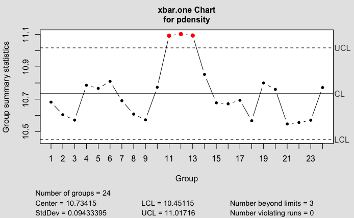

```r
library(qcc)
qcc(data = pdensity, type = "xbar.one")
```

```r
library(qcc)
qcc(pdensity,
type = "xbar.one",
restore.par = FALSE,
data.name = "Density of pellets", xlab = "Hour",
ylab = expression("Density gr/"*m^3), axes.las = 1)
```

[output not shown]

```r
abline(h = 10.5, col = "red",
lwd = 2)
```

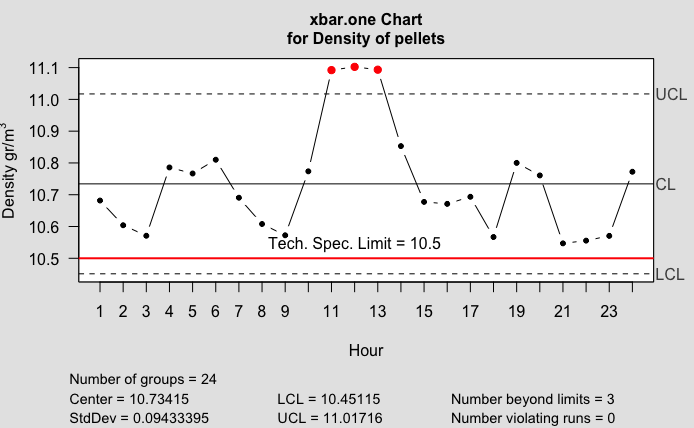

```r
text(x = 12,
y = 10.5,
labels = "Tech. Spec. Limit = 10.5",
pos = 3)
```